# COMPSCIX 415.2 Homework 9/Final

Xinmiao Tan

August 2, 2018

```r
library(tidyverse)
library(ggplot2)
library(broom)
```

### Exercise 1 - Sampling Distributions, Functions and For Loops (10 points)

#### Recall that the distribution of the sample mean is approximately a Normal distribution, and that the standard error is σ/sqrt(n) . This holds true regardless of the distribution of our population.

#### For this problem, assume that the number of miles that a particular car can run before its battery wears out is exponentially distributed with an average of 10,000 miles. The exponential distribution looks like this:

#### The exponential distribution has a rate parameter that controls how quickly the distribution decays and defines what the mean and standard deviation will be. In our case the rate = 1/10000, the mean = 10000 and the standard deviation = 10000. You can sample from this exponential distribution in R using this code:

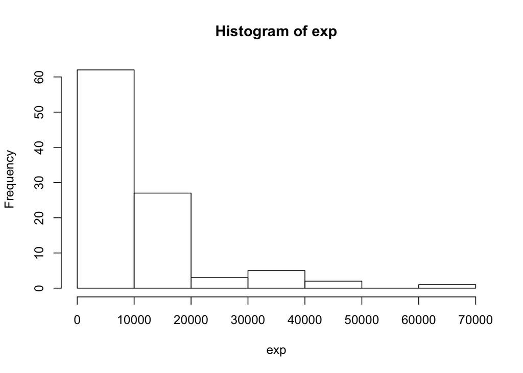

```r
# sample size
samp_size <- 100
# set the rate parameter
samp_rate <- 1/10000
# take sample
exp <- rexp(n = samp_size, rate = samp_rate)
hist(exp)
```

#### STEP 1

#### Write an R function that does the following:

##### • Takes a sample of size samp_size from this exponential distribution (samp_size is an input parameter for the function)

##### • Calculates the mean of that sample

##### • Calculates the standard deviation of that sample

##### • Returns the calculated mean and standard deviation as a list

```r
samp_fun <- function(samp_size, samp_rate) {
    sample <- rexp(n = samp_size, rate = samp_rate)
    samp_avg <- mean(sample)
    samp_std_dev <- sd(sample)
    stats <- list(samp_avg = samp_avg, samp_std_dev = samp_std_dev)
    return(stats)
}
samp_fun(100, 1/10000)
```

```
## $samp_avg
## [1] 10088.01
##
## $samp_std_dev
## [1] 10445.15
```

#### STEP 2

##### Then write a loop that does this:

##### • Runs the above function 1000 times, with samp_size = 50 and samp_rate = 1/10000

##### • Saves all of the sample means in a vector called sample_means, and all of the sample standard deviations in a vector called sample_sds

```r
n <- 1000 #how many samples
samp_size <- 50
sample_means <- rep(NA, n) # empty vector for saving coefficients
sample_sds <- rep(NA, n) # empty vector for saving coefficients

for(i in 1:n) {
    sample <- rexp(n = samp_size, rate = 1/10000)
    sample_means[i] <- mean(sample)
    sample_sds[i] <- sd(sample)
}
```

#### STEP 3

##### • plot your sample means as a histogram

##### • output the standard deviation of your sample means

##### • calculate the theoretical standard error (σ = 10000, n = sample size)

##### • calculate the mean of the sample standard deviations and use this to calculate the empirical standard error

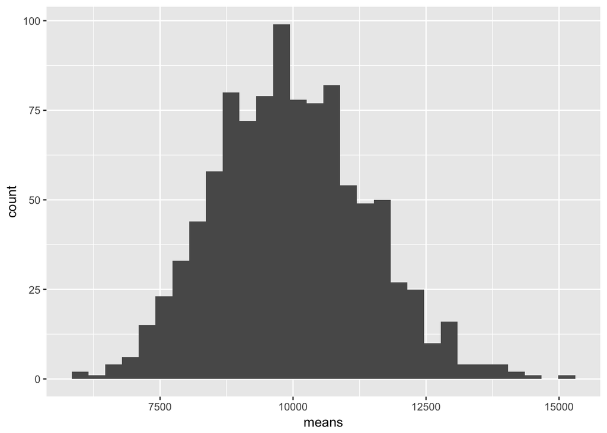

```r
means <- as_tibble(sample_means)
means %>% ggplot(aes(x=means))+
    geom_histogram()
```

```r
sd(sample_means)
```

```
## [1] 1417.352
```

```r
theoretical_se <- 10000/1000
theoretical_se
```

```
## [1] 10
```

```r
empirical_se <- mean(sample_sds)/1000
empirical_se
```

```
## [1] 9.750521
```

#### STEP 4

##### Repeat STEP 2 and STEP 3 using a sample size of 500 and 5000.

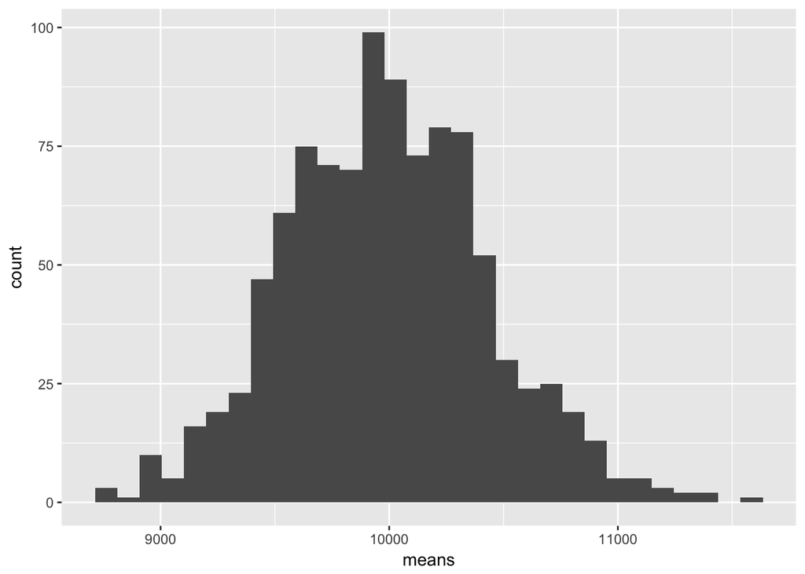

```r
#500
n <- 1000 #how many samples
samp_size <- 500
sample_means <- rep(NA, n) # empty vector for saving coefficients
sample_sds <- rep(NA, n) # empty vector for saving coefficients

for(i in 1:n) {
    sample <- rexp(n = samp_size, rate = 1/10000)
    sample_means[i] <- mean(sample)
    sample_sds[i] <- sd(sample)
}

means <- as_tibble(sample_means)
means %>% ggplot(aes(x=means))+
    geom_histogram()
```

```r
print(sd(sample_means))
```

```
## [1] 442.6037
```

```r
theoretical_se <- 10000/1000
print(theoretical_se)
```

```
## [1] 10
```

```r
empirical_se <- mean(sample_sds)/1000
print(empirical_se)
```

```
## [1] 9.989598
```

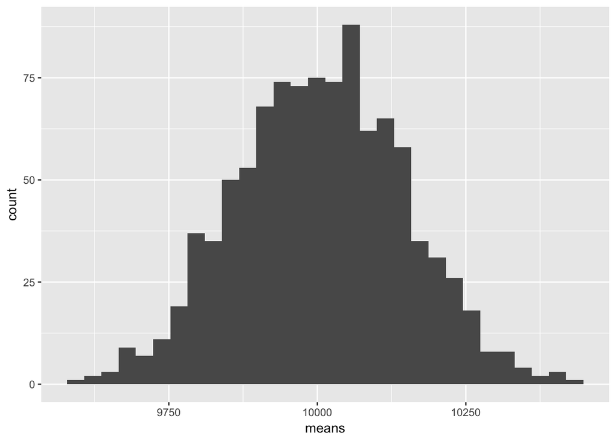

```r
#5000
n <- 1000 #how many samples
samp_size <- 5000
sample_means <- rep(NA, n) # empty vector for saving coefficients
sample_sds <- rep(NA, n) # empty vector for saving coefficients

for(i in 1:n) {
    sample <- rexp(n = samp_size, rate = 1/10000)
    sample_means[i] <- mean(sample)
    sample_sds[i] <- sd(sample)
}

means <- as_tibble(sample_means)
means %>% ggplot(aes(x=means))+
    geom_histogram()
```

```r
print(sd(sample_means))
```

```
## [1] 141.1518
```

```r
theoretical_se <- 10000/1000
print(theoretical_se)
```

```
## [1] 10
```

```r
empirical_se <- mean(sample_sds)/1000
print(empirical_se)
```

```
## [1] 9.99981
```

### Exercise 2 - Linear Regression (5 points)

#### For this exercise we will return to the House Prices prediction dataset that we used for HW 7. You should have already downloaded the train.csv dataset before, but if you didn’t you can download it from Canvas in this week’s module.

#### Load the train.csv dataset into R and fit a regression model with:

##### • Features: LotArea, OverallQual, and ExterQual

#### Answer these questions:

##### • Use the broom package to output the coefficients and the R-squared

##### • Interpret the coefficient on LotArea

##### • Interpret the coefficient on ExterQualGd

##### • Compare this model to the model we fit in HW 7 with GrLivArea, OverallQual, Neighborhood. Whichis the better fitting model?

```r
train_data <- read_csv('/Users/xinmiaotan/Desktop/Data Science/R/IntroR/Lec9/train.csv')
train_lm <- lm(formula = SalePrice ~ LotArea + OverallQual + ExterQual, data = train_data)
tidy(train_lm)
```

```
## # A tibble: 6 x 5
##          term      estimate    std.error  statistic       p.value
##         <chr>         <dbl>        <dbl>      <dbl>         <dbl>
## 1 (Intercept)  40763.572927 1.235785e+04   3.298598  9.951787e-04
## 2     LotArea      1.452925 1.161828e-01  12.505510  3.716127e-34
## 3 OverallQual  34466.192312 1.216110e+03  28.341336 4.774542e-141
## 4 ExterQualFa -95352.074546 1.459191e+04  -6.534584  8.800332e-11
## 5 ExterQualGd -71529.493394 6.737063e+03 -10.617312  2.053107e-25
## 6 ExterQualTA -97526.514185 7.541223e+03 -12.932454  2.722521e-36
```

```r
glance(train_lm)
```

```
## # A tibble: 1 x 11
##   r.squared adj.r.squared    sigma statistic p.value    df    logLik
## *     <dbl>         <dbl>    <dbl>     <dbl>   <dbl> <int>     <dbl>
## 1 0.6950118      0.693963 43948.08  662.6794       0     6 -17677.16
## # ... with 4 more variables: AIC <dbl>, BIC <dbl>, deviance <dbl>,
## #   df.residual <int>
```

```r
train_lm2 <- lm(formula = SalePrice ~ GrLivArea + OverallQual + Neighborhood, data = train_data)
tidy(train_lm2)
```

```
## # A tibble: 27 x 5
##                   term    estimate    std.error statistic      p.value
##                  <chr>       <dbl>        <dbl>     <dbl>        <dbl>
##  1         (Intercept) -34829.2399 11541.232315 -3.017809 2.591005e-03
##  2           GrLivArea     55.5645     2.498787 22.236587 2.375376e-94
##  3         OverallQual  20951.4249  1162.273747 18.026239 1.238994e-65
##  4 NeighborhoodBlueste -30752.8759 27697.270091 -1.110322 2.670468e-01
##  5  NeighborhoodBrDale -43358.8812 12978.523255 -3.340818 8.568095e-04
##  6 NeighborhoodBrkSide -13025.4529 10450.444653 -1.246402 2.128206e-01
##  7 NeighborhoodClearCr  24575.6351 11569.625542  2.124151 3.382834e-02
##  8 NeighborhoodCollgCr  11414.3095  9496.581581  1.201939 2.295858e-01
##  9 NeighborhoodCrawfor  14444.2502 10502.214763  1.375353 1.692371e-01
## 10 NeighborhoodEdwards -17842.9513  9985.733698 -1.786844 7.417398e-02
## # ... with 17 more rows
```

```r
glance(train_lm2)
```

```
## # A tibble: 1 x 11
##   r.squared adj.r.squared    sigma statistic p.value    df    logLik
## *     <dbl>         <dbl>    <dbl>     <dbl>   <dbl> <int>     <dbl>
## 1 0.7868484      0.782981 37008.52  203.4583       0    27 -17415.62
## # ... with 4 more variables: AIC <dbl>, BIC <dbl>, deviance <dbl>,
## #   df.residual <int>
```

When other factors are constant, with one unite increass in LotArea, the sales price will on average increase 1.452925. When other factors are constant, with one unite increase in OverallQual, the sales price will on average increase 34466.192312.

The R square for the new model is 0.6950118. And the R square for the HW7 model is 0.7868484. HW7 model is better.

### Exercise 3 - AB Testing (5 points)

#### Download the ab_test_data.csv file from Canvas. This file contains two columns: version and conversion. Each row is a visitor to a webpage. The version column tells us which version of the webpage the visitor saw, and the conversion column is a binary value and equals 1 if the visitor converted (0 otherwise).

#### We want to perform an AB test on this data to see if the conversion rates are different for the two versions of the webpage.

#### Answer these questions:

##### a. What proportion of visitors converted for each version of the webpage?

##### b. Perform the AB test in R. What is the p-value for the AB test (hypothesis test of proportions)?

```r
ab_test_data <- read_csv('/Users/xinmiaotan/Desktop/Data Science/R/IntroR/Lec9/ab_test_data.csv')
samp_a <- ab_test_data[ab_test_data$version=='A',]
samp_b <- ab_test_data[ab_test_data$version=='B',]

nrow(samp_a[samp_a$conversion==1,])/nrow(samp_a)
```

```
## [1] 0.0415
```

```r
nrow(samp_b[samp_b$conversion==1,])/nrow(samp_b)
```

```
## [1] 0.1
```

```r
two_prop_test <- prop.test(c(nrow(samp_a[samp_a$conversion==1,]), nrow(samp_b[samp_b$conversion==1,])), c(nrow(samp_a), nrow(samp_b)))
two_prop_test$p.value
```

```
## [1] 8.479709e-13
```

Version A conversion prop: 0.0415. Version B concersion prop: 0.1

The P valuse is 8.479709e-13.